# hw5

2022-11-17

Set up

```r
library(tidymodels)
library(tidyverse)
```

```r
library(dplyr)
#library(corrr)
library(ggplot2)
library(discrim)
library(klaR)
library(glmnet)
tidymodels_prefer()
pokemon <- read.csv("data/Pokemon.csv")
set.seed(1234)
head(pokemon)
```

```
##   X.                  Name Type.1 Type.2 Total HP Attack Defense Sp..Atk
## 1  1             Bulbasaur  Grass Poison   318 45     49      49      65
## 2  2               Ivysaur  Grass Poison   405 60     62      63      80
## 3  3              Venusaur  Grass Poison   525 80     82      83     100
## 4  3 VenusaurMega Venusaur  Grass Poison   625 80    100     123     122
## 5  4            Charmander   Fire          309 39     52      43      60
## 6  5            Charmeleon   Fire          405 58     64      58      80
##   Sp..Def Speed Generation Legendary
## 1      65    45          1     False
## 2      80    60          1     False
## 3     100    80          1     False
## 4     120    80          1     False
## 5      50    65          1     False
## 6      65    80          1     False
```

Question 1

```r
library(janitor)
pokemon <- pokemon %>%
  clean_names() #names lowercase without periods/commas
#now underscore
```

With clean_names(), we see that the variables how are all lowercase and don’t have periods or commas anymore and are replaced with underscore. This is useful so that the variables have a consistent variable format.

Question 2

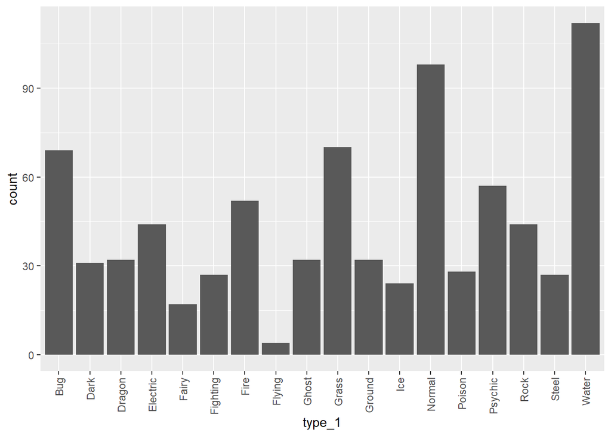

```r
barchart <- ggplot(data = pokemon, aes(x = type_1)) +
  geom_bar() +
  theme(axis.text.x = element_text(angle = 90, vjust = 0.5, hjust=1))
barchart
```

```r
#filter out rarer classes
pokemon_filter <- pokemon %>%
  filter(type_1 == c("Bug", "Fire", "Grass", "Normal", "Water", "Psychic"))
pokemon_factor <- pokemon_filter %>%
  mutate(type_1 = factor(type_1),
         legendary = factor(legendary),
         generation = factor(generation))
```

There are 18 classes of type_1. There are a few Pokemon that are Flying and Fairy. There are also around 35 or less Pokemon that are Dark, Dragon, Fighting, Ghost, Ground, Ice, Poison, and Steel.

Exercise 3

```r
pokemon_split <- initial_split(pokemon_factor,
                               prop = 0.80,
                               strata = type_1)
pokemon_split
```

```
## <Training/Testing/Total>
## <63/19/82>
```

```r
pokemon_train <- training(pokemon_split)
pokemon_test <- testing(pokemon_split)

pokemon_folds <- vfold_cv(pokemon_train, v = 5,
                          strata = type_1)
pokemon_folds
```

```
## #  5-fold cross-validation using stratification
## # A tibble: 5 × 2
##   splits          id
##   <list>          <chr>
## 1 <split [48/15]> Fold1
## 2 <split [49/14]> Fold2
## 3 <split [50/13]> Fold3
## 4 <split [52/11]> Fold4
## 5 <split [53/10]> Fold5
```

Stratifying the folds might be useful as we could divide also by the type of Pokemon to analyze.

Exercise 4

```r
pokemon_recipe <-
  recipe(type_1 ~ legendary + generation + sp_atk + attack + speed + defense +
           hp + sp_def, data = pokemon_train) %>%
  step_dummy(c("legendary", "generation")) %>% #all_nominal_predictors?
  step_center(all_predictors()) %>%
  step_scale(all_predictors())
pokemon_recipe
```

```
## Recipe
##
## Inputs:
##
##       role #variables
##    outcome          1
##  predictor          8
##
## Operations:
##
## Dummy variables from c("legendary", "generation")
## Centering for all_predictors()
## Scaling for all_predictors()
```

Exercise 5

```r
multi_model <- multinom_reg(mixture = tune(), penalty = tune()) %>%
  set_engine("glmnet") %>%
  set_mode("classification")
multi_model
```

```
## Multinomial Regression Model Specification (classification)
##
## Main Arguments:
##   penalty = tune()
##   mixture = tune()
##
## Computational engine: glmnet
```

```r
multi_wrkflow <- workflow() %>%
  add_model(multi_model) %>%
  add_recipe(pokemon_recipe)

pokemon_grid <- grid_regular(penalty(range = c(-5, 5)),
                             mixture(range = c(0, 1)), levels = 10)
pokemon_grid
```

```
## # A tibble: 100 × 2
##          penalty mixture
##            <dbl>   <dbl>
##  1      0.00001        0
##  2      0.000129       0
##  3      0.00167        0
##  4      0.0215         0
##  5      0.278          0
##  6      3.59           0
##  7     46.4            0
##  8    599.             0
##  9   7743.             0
## 10 100000              0
## # … with 90 more rows
```

I’ll be fitting 100 models.